# Vegetation index (VI) extractions using RGB orthomosaic images

Leonardo Volpato

Last compiled on 19 December, 2022

# About this analysis

The present analysis aims to perform the VIs extractions from the RGB images aka orthomosaic. Data source: Dry Beans Breeding Program - MSU. Principal Investigator: [Dr. Francisco Gomez](https://www.canr.msu.edu/people/francisco-gomez)

## Resources

- Basic pipeline
- Getting started - Complete data set
  - Running the loops
  - Adjusting the results and saving

## Setting up the working directory

```r
rm(list=ls())
my.path <- dirname(rstudioapi::getActiveDocumentContext()$path)
setwd(my.path)
```

## Load and install necessary Packages

```r
# if(!require(pacman)) install.packages(pacman)
#
# pacman::p_load(
#                     sp,
#                     #raster,
#                     terra,
#                     rgdal,
#                     ggplot2,
#                     agricolae,
#                     reshape2,
#                     devtools,
#                     ggrepel,
#                     lme4,
#                     plyr,
#                     DescTools,
#                     doParallel,
#                     parallel,
#                     foreach,
#                     maptools,
#                     spatialEco,
#                     attempt,
#                     igraph,
#                     config,
#                     BiocManager,
#                     EBImage,
#                     FIELDimageR,
#                     tidyr
# )
```

# 1 Basic pipeline

## 1.1 Setting the work directories

A example soybean files will be used to perform this introduction pipeline. As reference see Volpato et al. 2021

- The example data contain: 2 orthomosaic and a shapefile with 48 plots in total.

### 1.1.1 Folder directory containing the orthomosaics

```r
dir_ortho <- "/MOSAIC"
dir_ortho <- paste(my.path,dir_ortho, sep="")
print(dir_ortho)
```

```
#> [1] "G:/Shared drives/Bean_Lab/Volpato/R_script/Phenotyping-drones-img/VIs/VIs_RGB_v2/Workshop_01_VIs/MOSAIC"
```

### 1.1.2 Folder directory containing the shapefiles

```r
folder_shp <- "./Shapefile"
```

## 1.2 Getting the files

```r
imgFiles <-list.files(path = dir_ortho, pattern="*.tif$",full.names = T) #get the Orthosaics.
imgFiles #Files that their name ends in group1.tif (Change all file names to otimization)
```

```
#> [1] "G:/Shared drives/Bean_Lab/Volpato/R_script/Phenotyping-drones-img/VIs/VIs_RGB_v2/Workshop_01_VIs/MOSAIC/WA_2018_08_15.tif"
#> [2] "G:/Shared drives/Bean_Lab/Volpato/R_script/Phenotyping-drones-img/VIs/VIs_RGB_v2/Workshop_01_VIs/MOSAIC/WA_2018_08_23.tif"
```

```r
imgFiles_name <-list.files(path = dir_ortho, pattern="*.tif$") # Aux file names
imgFiles_name <- gsub(".tif", "", imgFiles_name, ignore.case = FALSE, perl = FALSE, fixed = TRUE, useBytes = FALSE) # Removing the extension
imgFiles_name
```

```
#> [1] "WA_2018_08_15" "WA_2018_08_23"
```

## 1.3 Loading and Reading the plots Shapefile

```r
# Loading the shape files
layer_prefix_shp <- "Export_Output" # name with the .shp extension
## Read the plots Shapefile
#indPlots <- readOGR(dsn = folder_shp, layer = layer_prefix_shp)
indPlots <- vect( folder_shp, layer = layer_prefix_shp)

## Polygon plot ID list from the shapefiles
names(indPlots)
```

```
#> [1] "Range2"     "Row2"       "Test"       "Entry"      "MNPlot"     "RM"
#> [7] "RM_list"    "RepNo"      "MaturityDa"
```

## 1.4 Getting the RGB bands

```r
#img_ortho <- imgFiles[1]
img.rgb.1 <- rast(imgFiles[1])
img.rgb.1
```

```
#> class       : SpatRaster
#> dimensions  : 1582, 836, 4  (nrow, ncol, nlyr)
#> resolution  : 0.02535, 0.02535  (x, y)
#> extent      : 457926.1, 457947.2, 4880222, 4880262  (xmin, xmax, ymin, ymax)
#> coord. ref. : WGS 84 / UTM zone 15N (EPSG:32615)
#> source      : WA_2018_08_15.tif
#> names       : WA_2018_08_15_1, WA_2018_08_15_2, WA_2018_08_15_3, WA_2018_08_15_4
#> min values  :              36,              40,               1,             255
#> max values  :             254,             252,             225,             255
```

## 1.5 Ploting the field maps and shapefile

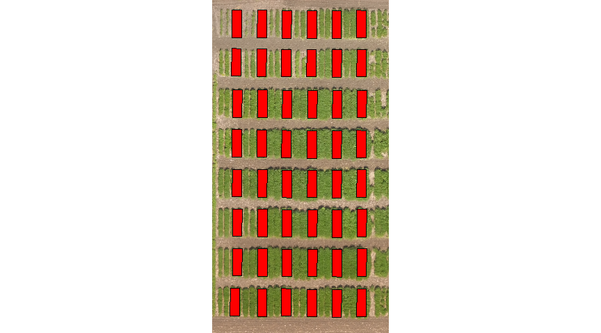

```r
plotRGB(img.rgb.1)

plot(indPlots,add=T,col="red") # merge the external shp file and orthomosaic
```

## 1.6 Reducing the image resoution if necessary

```r
img.rgb.2<-aggregate(img.rgb.1, fact=4) ## reducing the resoluation. Using high numbers for fact is not desired.
```

## 1.7 Cropping the plot image

```r
plot_crop_idx_1 <- crop(img.rgb.1,ext(indPlots[1,]))
```

## 1.8 Plotting the plot image

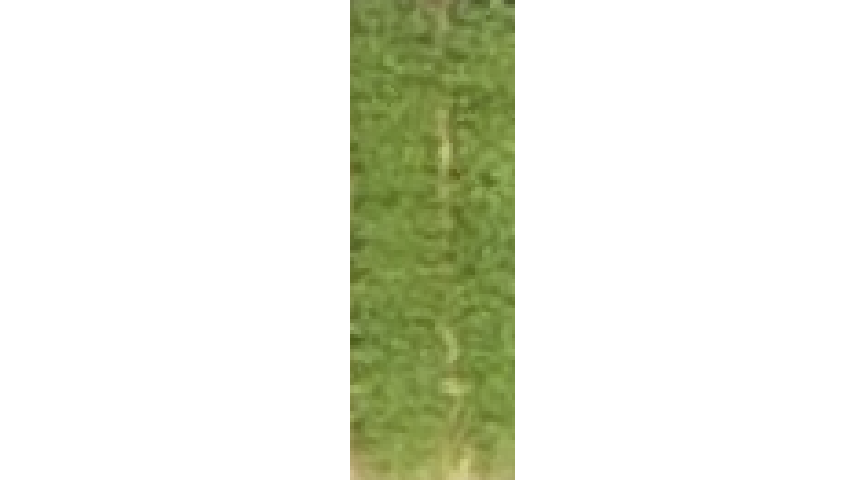

```r
plotRGB(plot_crop_idx_1)
```

## 1.9 Building vegetation indices

- The R package `FIELDimageR` will be used to perform this step. Referene: [Filipe Matias](https://github.com/OpenDroneMap/FIELDimageR/blob/master/README.md)

```
#> [1] "4 layers available"
```

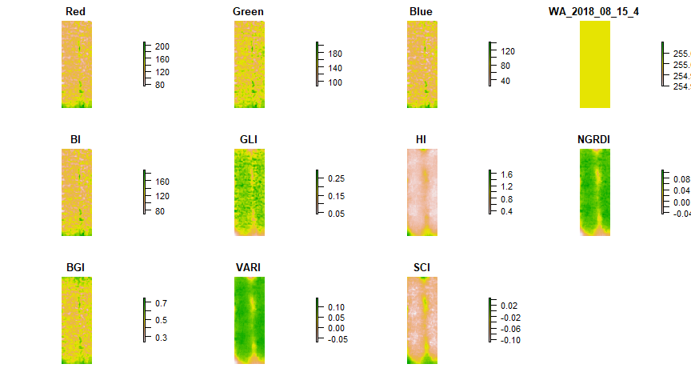

```r
img.index <- fieldIndex(mosaic = plot_crop_idx_1, index = c("BI", "GLI", "HI", "NGRDI", "BGI", "VARI", "SCI"))
```

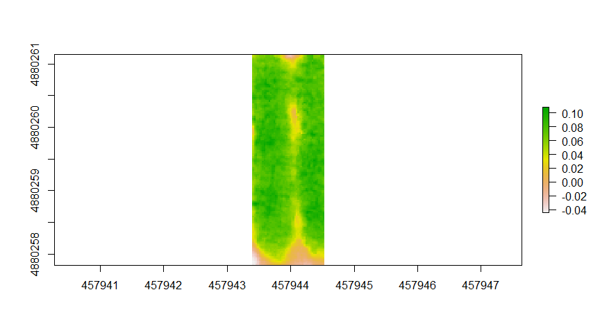

```r
plot(img.index$NGRDI)
```

## 1.10 Removing the soil

- The R package `FIELDimageR` will be used to perform this step.
- Choosing the best index to build a mask for RGB
- This is a trick analysis to run, but this criteria is up to the research to pick one threshold and VIs

```
#> [1] "4 layers available"
```

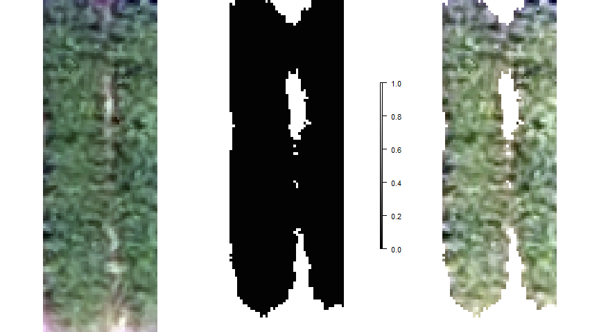

```r
EX.Mask1 <- fieldMask(mosaic = plot_crop_idx_1, index = "NGRDI", cropValue = 0.05, cropAbove = F)
```

```
#> [1] "4 layers available"
```

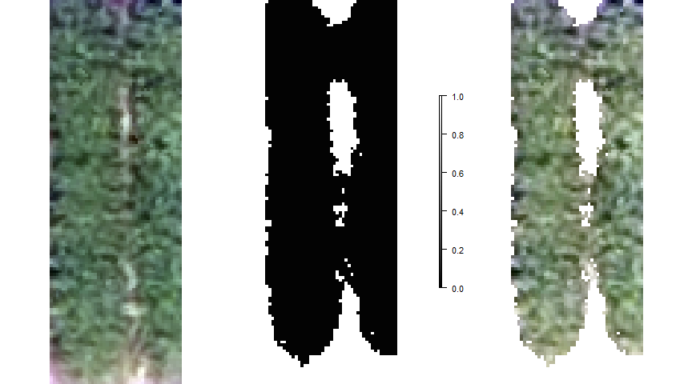

```r
EX.Mask3 <- fieldMask(mosaic = plot_crop_idx_1, index = "HI", cropValue = 0.6, cropAbove = T) #all values above the cropValue will be accounted to make the mask.
```

```
#> [1] "4 layers available"
```

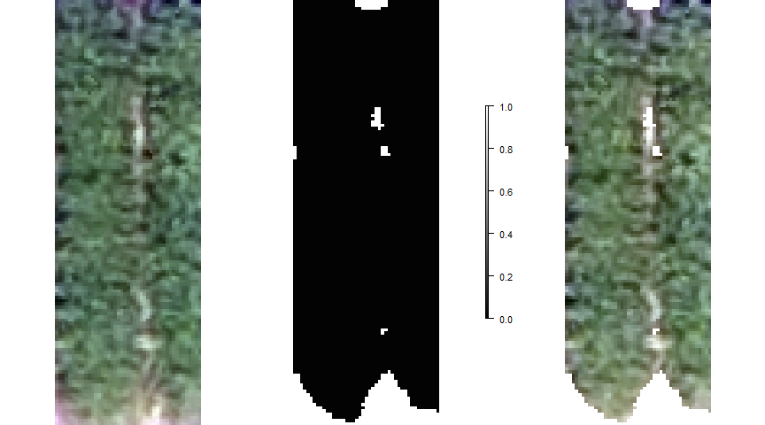

```r
EX.Mask4 <- fieldMask(mosaic = plot_crop_idx_1, index = "HI", cropValue = 0.8, cropAbove = T)
```

```
#> [1] "4 layers available"
```

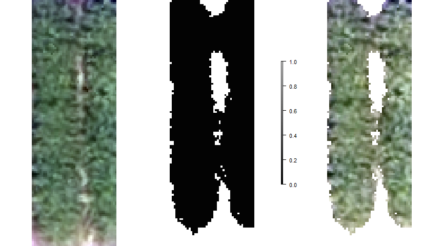

```r
EX.Mask5 <- fieldMask(mosaic = plot_crop_idx_1, index = "HI", cropValue = 0.6, cropAbove = T) ## This model will be select to perform the analysis
```

## 1.11 Building vegetation indices

```
#> [1] "4 layers available"
```

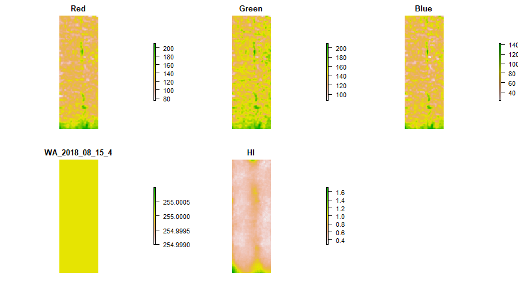

```r
#Investigating the raw image plot
img.index.hi <- fieldIndex(mosaic = plot_crop_idx_1, index = c("HI") )
```

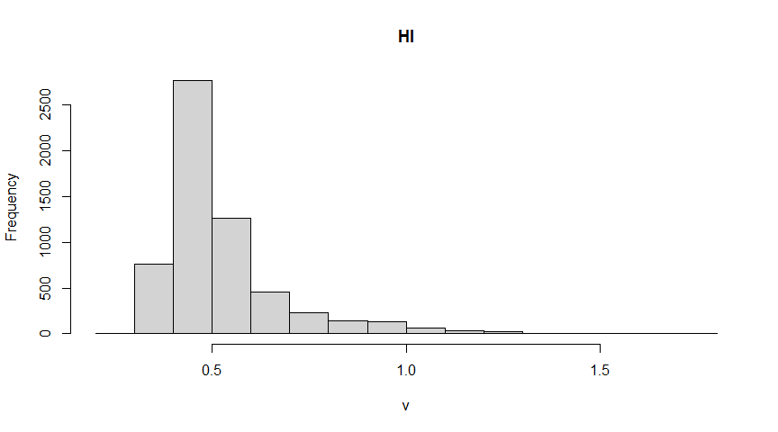

```r
hist(img.index.hi$HI) # Image segmentation start from 0.7 (soil and plants)
```

```
#> [1] "4 layers available"
```

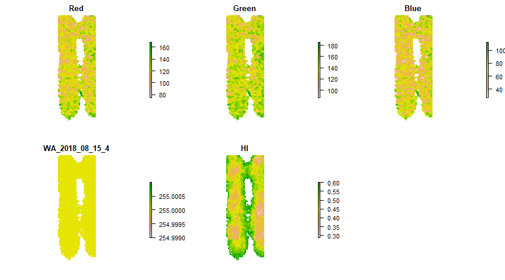

```r
#Investigating the clean image plot
img.index.hi.clean <- fieldIndex(mosaic = EX.Mask5$newMosaic, index = c("HI") )
```

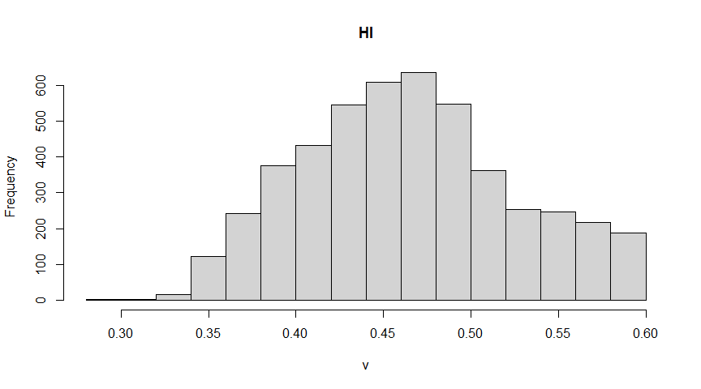

```r
hist(img.index.hi.clean$HI) # Image segmentation start from 0.7 (soil and plants)
```

## 1.12 Orthomosaic image

```
#> [1] "4 layers available"
```

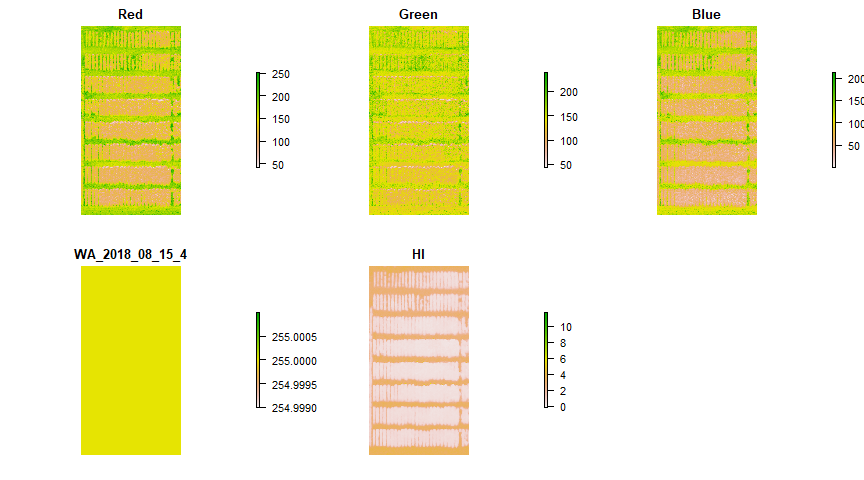

```r
ortho.index.hi.clean<- fieldIndex(mosaic = img.rgb.1, index = c("HI"))
```

```
#> [1] "4 layers available"
```

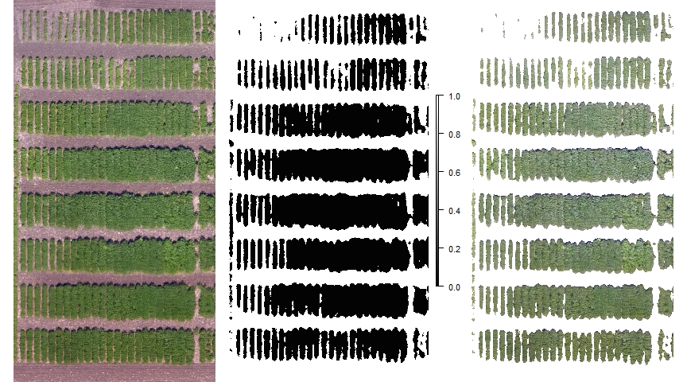

```r
#dev.off()

ortho.HI.RemSoil<- fieldMask(mosaic = img.rgb.1, Red = 1, Green = 2, Blue = 3,
                   index = "HI", cropValue = 0.7, cropAbove = T)
```

## 1.13 Extracting the pixels values

```
#> [1] "4 layers available"
```

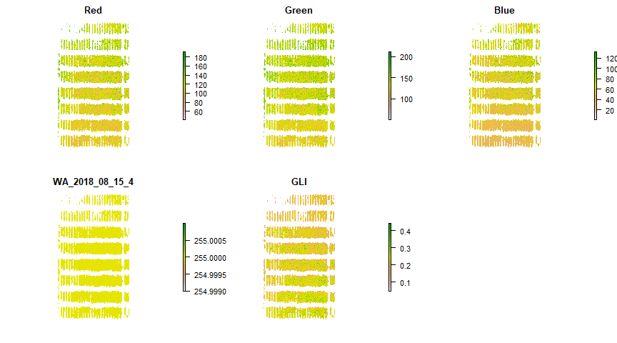

```r
##Selection the VI from the clean orthomosaic
Veg.Indices<-fieldIndex(mosaic = ortho.HI.RemSoil$newMosaic,
                        index=c("GLI"))
```

```r
## Read the plots Shapefile
indPlots <- readOGR(dsn = folder_shp, layer = layer_prefix_shp)
#indPlots <- read_sf(dsn = folder_shp, layer = layer_prefix_shp)

## Conf. the CRS projections
projection(indPlots)<-projection(Veg.Indices) ##Makes coordinate system of .tif with indices and without soil and .shp the same


ortho.Info1<-fieldInfo(mosaic=Veg.Indices,
                     fieldShape=indPlots,
                     n.core=10) ## Extracts all vegetation indices (layers) for each .shp file
```

```
#> [1] "Extracting: 5 layers."
#> [1] "You can speed up this step using n.core=12 or less."
```

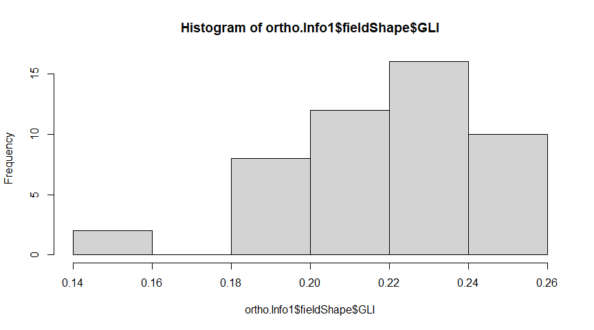

```r
VI_data<- dplyr::as_tibble(ortho.Info1$fieldShape@data)

write.csv(VI_data, "VI_data_GLI.csv",  row.names=F)

hist(ortho.Info1$fieldShape$GLI)
```

## 1.14 Graphic visualization of trait values for each plot using the fieldShape file and the orthomosaic

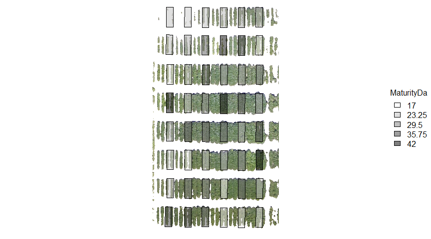

```r
#names(indPlots)
### Interpolating colors: c("white","black")
fieldPlot(fieldShape=ortho.Info1$fieldShape,fieldAttribute="MaturityDa", mosaic=Veg.Indices, color=c("white","black"), alpha = 0.5)
```

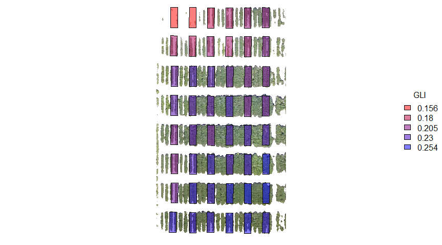

```r
### Interpolating colors: c("red","blue")
fieldPlot(fieldShape=ortho.Info1$fieldShape,fieldAttribute="GLI", mosaic=Veg.Indices, color=c("red","blue"), alpha = 0.5)
```

## 1.15 Getting started - Complete data set

This code will run across of 4 type of loops: * Flgith date (orthomosaic) **i** * Vegetation index (VIs) **v** * Function of pixel value extraction **f** * Plot ID **p**

**ATTENTION** - This script will run using the [parallel function](https://stat.ethz.ch/R-manual/R-devel/library/parallel/doc/parallel.pdf) to improve the computer capacity, however, be aware that you computer will be dedicated only for this analysis. To avoid any crash, reduce the number of cores to -2 from your total number.

## 1.16 Setting up the working directory

```r
rm(list=ls())
my.path <- dirname(rstudioapi::getActiveDocumentContext()$path)
setwd(my.path)
```

# 2 Setting the work directories

## 2.1 Folder directory containing the orthomosaics

```r
dir_ortho <- "/MOSAIC"
dir_ortho <- paste(my.path,dir_ortho, sep="")
print(dir_ortho)
```

```
#> [1] "G:/Shared drives/Bean_Lab/Volpato/R_script/Phenotyping-drones-img/VIs/VIs_RGB_v2/Workshop_01_VIs/MOSAIC"
```

## 2.2 Folder directory containing the shapefiles

```r
folder_shp <- "./Shapefile"
```

# 3 Getting the files

```r
imgFiles <-list.files(path = dir_ortho, pattern="*.tif$",full.names = T) #get the Orthosaics.
imgFiles #Files that their name ends in group1.tif (Change all file names to otimization)
```

```
#> [1] "G:/Shared drives/Bean_Lab/Volpato/R_script/Phenotyping-drones-img/VIs/VIs_RGB_v2/Workshop_01_VIs/MOSAIC/WA_2018_08_15.tif"
#> [2] "G:/Shared drives/Bean_Lab/Volpato/R_script/Phenotyping-drones-img/VIs/VIs_RGB_v2/Workshop_01_VIs/MOSAIC/WA_2018_08_23.tif"
```

```r
imgFiles_name <-list.files(path = dir_ortho, pattern="*.tif$") # Aux file names
imgFiles_name <- gsub(".tif", "", imgFiles_name, ignore.case = FALSE, perl = FALSE, fixed = TRUE, useBytes = FALSE) # Removing the extension
imgFiles_name
```

```
#> [1] "WA_2018_08_15" "WA_2018_08_23"
```

# 4 Loading and Reading the plots Shapefile

```r
# Loading the shape files
layer_prefix_shp <- "Export_Output" # name with the .shp extension
## Read the plots Shapefile
#indPlots <- readOGR(dsn = folder_shp, layer = layer_prefix_shp)
indPlots <- readOGR( folder_shp, layer = layer_prefix_shp)
## Polygon plot ID list from the shapefiles
names(indPlots)
```

```
#> [1] "Range2"     "Row2"       "Test"       "Entry"      "MNPlot"     "RM"
#> [7] "RM_list"    "RepNo"      "MaturityDa"
```

```r
# Subsetting plots to speed up the loop
indPlots<- indPlots[1:5,"MNPlot"]
indPlots
```

```
#> class       : SpatialPolygonsDataFrame
#> features    : 5
#> extent      : 457931.5, 457944.5, 4880257, 4880261  (xmin, xmax, ymin, ymax)
#> crs         : +proj=utm +zone=15 +datum=WGS84 +units=m +no_defs
#> variables   : 1
#> names       : MNPlot
#> min values  : 264001
#> max values  : 264033
```

# 5 Setting the parameters from the loop

## 5.1 Plots ID

```r
## Data frame with plot names
Plot_ID<- as.data.frame(indPlots[,"MNPlot"])
indPlots # Plot identification propose
```

```
#> class       : SpatialPolygonsDataFrame
#> features    : 5
#> extent      : 457931.5, 457944.5, 4880257, 4880261  (xmin, xmax, ymin, ymax)
#> crs         : +proj=utm +zone=15 +datum=WGS84 +units=m +no_defs
#> variables   : 1
#> names       : MNPlot
#> min values  : 264001
#> max values  : 264033
```

## 5.2 VIs list

- The VIs list will be imported from a separated R script in order to the script maximization

```r
## Import the functions file
source("VIs_RGB-aux.R")

#Reading 38 VIs from RGB image
myIndex_list<- myIndex_list
myIndex_list_name<- myIndex_list_name
```

## 5.3 Functions of extractions

```r
func_list<- c('mean', 'median') # "sd
# There are many other functions (SD, VAR, Quantiles, etc)
```

## 5.4 Starting the parallel function

Please, take your time and study how this function works and if this function is for you.

```r
gc() #Cleaning unusual memmory
```

```
#>           used  (Mb) gc trigger  (Mb) max used  (Mb)
#> Ncells 4579540 244.6    8014052 428.0  8014052 428.0
#> Vcells 6658941  50.9   23408984 178.6 45720669 348.9
```

```r
# Number of cores
n.core<-detectCores() # or detectCores()

# Starting parallel
cl <- makeCluster(n.core, output = "")
registerDoParallel(cl)
getDoParWorkers()
```

```
#> [1] 12
```

## 5.5 Running the loops

- This loop can take up to 5* min to complete
- - See the computer resources restrictions

```r
## Using the code inside the system time to get the total time used.
system.time(
  for(i in 1:length(imgFiles)){ #loop through images

    message("Processing ortho: ",paste(imgFiles_name[i]))
    #i.h<-aggregate(stack(imgFiles[k]), fact=aggregateCells) to reduce the image size if the case
    i.h <-  stack(imgFiles[i])

    for(v in 1:length(myIndex_list)){ #loop through VIs

      message("Using VI: ",paste(myIndex_list_name[v]))

      for(f in 1:length(func_list)){  #loop through extractions functions

        message("Using function: ",paste(func_list[f]))

  results<- foreach(p = 1:length(indPlots),  #loop through plots numbers
                     .packages = c("raster", "FIELDimageR"),
                     .combine = rbind) %dopar% {

    # Step 1: crop the plot from the orthomosaci
    h.c <-  crop(i.h, extent(indPlots[p,]))

    # Step 2: remove the soil using the HUE VI with a threshold = 0.6
    m.h <-  fieldMask(mosaic=h.c,
                           Red=1,
                           Green=2,
                           Blue=3,
                           index="HUE",
                           cropValue=0.6, #or 0.6 | 0.8
                           cropAbove=T, ## Removes any instance of soil from tif file
                           plot = FALSE)

    # Step 3: Obtain the VI from the vegetation only
    Veg.Indices<-fieldIndex(mosaic = m.h$newMosaic, myIndex=myIndex_list[v],
    plot = FALSE)

    projection(indPlots)<-projection(Veg.Indices)

    # Step 4: Extraction the pixel value from each individual plot using the function
     raster::extract(x = Veg.Indices$myIndex, y = indPlots[p,], fun = eval(parse(text = func_list[f])),
            buffer = buffer, na.rm = T, df = T)

                     }

       results$Func<-func_list[f]

    # Step 5: Saving the results into a data frame with the lenght of the Plots ID
       results$ID <- 1:length(indPlots)

  if(f==1){results.1<-results}else{results.1<-rbind(results.1, results)}

      }

    # Step 6: Saving the vegetation index name for each function
      results.1$VIs<-myIndex_list_name[v]

     if(v==1){results.2<-results.1}else{results.2<-rbind(results.2, results.1)}

    }

    # # Step 6: Saving the vegetation index name from each function for each orthomosaic
      results.2$imgFiles_name<-imgFiles_name[i]

        if(i==1){results.3<-results.2}else{results.3<-rbind(results.3, results.2)}

  })
```

```
#>    user  system elapsed
#>    1.60    1.09  145.23
```

```r
parallel::stopCluster(cl) # Stopping the parallel function


###### the end ###########
```

## 5.6 Adjusting the results and saving

```r
as_tibble(results.3) # Saving into a table
```

| ID | myIndex | Func | VIs | imgFiles_name |
| --- | --- | --- | --- | --- |
| 1 | 114.9137065 | mean | BI | WA_2018_08_15 |
| 2 | 117.8167882 | mean | BI | WA_2018_08_15 |
| 3 | 118.7206208 | mean | BI | WA_2018_08_15 |
| 4 | 119.6909758 | mean | BI | WA_2018_08_15 |
| 5 | 134.2669836 | mean | BI | WA_2018_08_15 |
| 1 | 114.0701535 | median | BI | WA_2018_08_15 |
| 2 | 116.3127967 | median | BI | WA_2018_08_15 |
| 3 | 118.2553734 | median | BI | WA_2018_08_15 |
| 4 | 119.5226617 | median | BI | WA_2018_08_15 |
| 5 | 134.3366418 | median | BI | WA_2018_08_15 |
| 1 | 14.8269631 | mean | BIM | WA_2018_08_15 |
| 2 | 15.0217889 | mean | BIM | WA_2018_08_15 |
| 3 | 15.1032322 | mean | BIM | WA_2018_08_15 |
| 4 | 15.1978087 | mean | BIM | WA_2018_08_15 |
| 5 | 16.1635149 | mean | BIM | WA_2018_08_15 |
| 1 | 14.7873820 | median | BIM | WA_2018_08_15 |
| 2 | 14.9443412 | median | BIM | WA_2018_08_15 |
| 3 | 15.0775772 | median | BIM | WA_2018_08_15 |
| 4 | 15.1877143 | median | BIM | WA_2018_08_15 |
| 5 | 16.1864141 | median | BIM | WA_2018_08_15 |
| 1 | -0.0704816 | mean | SCI | WA_2018_08_15 |
| 2 | -0.0605880 | mean | SCI | WA_2018_08_15 |
| 3 | -0.0503409 | mean | SCI | WA_2018_08_15 |
| 4 | -0.0517345 | mean | SCI | WA_2018_08_15 |
| 5 | -0.0197081 | mean | SCI | WA_2018_08_15 |
| 1 | -0.0757576 | median | SCI | WA_2018_08_15 |
| 2 | -0.0671378 | median | SCI | WA_2018_08_15 |
| 3 | -0.0553506 | median | SCI | WA_2018_08_15 |
| 4 | -0.0575540 | median | SCI | WA_2018_08_15 |
| 5 | -0.0175439 | median | SCI | WA_2018_08_15 |

[output cut: 730 more lines]

```r
# Adjusting the data for VIs and Func columns
results.final<-tidyr::pivot_wider(results.3, names_from   = c("VIs", "Func"),
                           values_from = "myIndex")

head(results.final)
```

| ID | imgFiles_name | BI_mean | BI_median | BIM_mean | BIM_median | SCI_mean | SCI_median | GLI_mean | GLI_median | HI_mean | HI_median | NGRDI_mean | NGRDI_median | SI_mean | SI_median | VARI_mean | VARI_median | HUE_mean | HUE_median | BdivG_mean | BdivG_median | BCC_mean | BCC_median | CIVE_mean | CIVE_median | COM1_mean | COM1_median | COM2_mean | COM2_median | … |
| --- | --- | --- | --- | --- | --- | --- | --- | --- | --- | --- | --- | --- | --- | --- | --- | --- | --- | --- | --- | --- | --- | --- | --- | --- | --- | --- | --- | --- | --- | --- |
| 1 | WA_2018_08_15 | 114.9137 | 114.0702 | 14.82696 | 14.78738 | -0.0704816 | -0.0757576 | 0.1995143 | 0.2025586 | 0.5117505 | 0.4750000 | 0.0704816 | 0.0757576 | 0.3022752 | 0.3000000 | 0.0936563 | 0.1009615 | -1.558495 | -1.566783 | 0.4675605 | 0.4662162 | 0.1996195 | 0.2000000 | -15.926257 | -16.82305 | 140.59841 | 146.33995 | 26.23870 | 26.58392 | … |
| 2 | WA_2018_08_15 | 117.8168 | 116.3128 | 15.02179 | 14.94434 | -0.0605880 | -0.0671378 | 0.1901689 | 0.1945701 | 0.5739090 | 0.5263158 | 0.0605880 | 0.0671378 | 0.3028373 | 0.3010753 | 0.0804949 | 0.0896226 | -1.541007 | -1.566420 | 0.4766734 | 0.4718310 | 0.2011394 | 0.2007299 | -14.829167 | -15.98155 | 132.79554 | 139.99804 | 25.87120 | 26.33065 | … |
| 3 | WA_2018_08_15 | 118.7206 | 118.2554 | 15.10323 | 15.07758 | -0.0503409 | -0.0553506 | 0.1791316 | 0.1830986 | 0.6357637 | 0.5937500 | 0.0503409 | 0.0553506 | 0.2996707 | 0.2984293 | 0.0672337 | 0.0744186 | -1.534782 | -1.565780 | 0.4895181 | 0.4844720 | 0.2039526 | 0.2035928 | -13.165931 | -14.57255 | 123.18016 | 129.82069 | 25.21568 | 25.83034 | … |
| 4 | WA_2018_08_15 | 119.6910 | 119.5227 | 15.19781 | 15.18771 | -0.0517345 | -0.0575540 | 0.1724717 | 0.1779141 | 0.6091133 | 0.5675676 | 0.0517345 | 0.0575540 | 0.2781875 | 0.2777778 | 0.0701976 | 0.0781250 | -1.535189 | -1.565822 | 0.5112599 | 0.5037037 | 0.2113883 | 0.2105263 | -12.217902 | -13.46955 | 119.45166 | 126.36505 | 24.75854 | 25.24455 | … |
| 5 | WA_2018_08_15 | 134.2670 | 134.3366 | 16.16351 | 16.18641 | -0.0197081 | -0.0175439 | 0.1298501 | 0.1285732 | 0.8255476 | 0.8360656 | 0.0197081 | 0.0175439 | 0.2488343 | 0.2468619 | 0.0276502 | 0.0249378 | -1.423428 | -1.556806 | 0.5799225 | 0.5816298 | 0.2278412 | 0.2285714 | -6.486889 | -5.74205 | 82.94439 | 79.11988 | 22.64511 | 22.35350 | … |
| 1 | WA_2018_08_23 | 120.4437 | 119.0602 | 15.23552 | 15.18771 | -0.0564229 | -0.0579710 | 0.1730734 | 0.1721612 | 0.5612855 | 0.5428571 | 0.0564229 | 0.0579710 | 0.2680846 | 0.2641509 | 0.0772911 | 0.0798122 | -1.559828 | -1.565947 | 0.5180355 | 0.5208333 | 0.2143073 | 0.2157434 | -12.306567 | -12.93855 | 120.79662 | 123.21057 | 24.75331 | 25.01391 | … |

```r
# Saving
write.csv(results.final, "test01_MRF_RGB.csv", quote = F, row.names = F)
```